# Methods and Results Summary

ROSSyndicate

2024-05-28

# Introduction

Remote sensing image classification is common in terrestrial applications (in particular, land use and land cover), but has not been applied in aquatic environments beyond general presence and absence of water and wetlands. The primary exception to the use of image classification in aquatic environments is assessing the presence of submerged aquatic vegetation (“SAV”) (e.g., E. L. Hestir, J. A. Greenberg, and S. L. Ustin (2012)); however, these classification methods require high resolution imagery with high spectral resolution often from land-based high-resolution photography or unpersoned aerial vehicles (“UAVs”).

In the Great Lakes (GL) region, much of the use of image classification is completed using moderate resolution (e.g., Landsat, Sentinel, MODIS) satellite images, focusing on mapping the distribution and types of wetlands throughout the region (V. L. Valenti et al. (2020)), as well as SAV distribution throughout the system (Wolter, Johnston, and Niemi 2005). Most of these analyses focus on a relatively short temporal period (months to years), while a some span the entire Landsat archive from the mid ’80s through the recent past (e.g., (Amani et al. 2022)).

In this analysis, we use the Landsat Collection 2 Surface Reflectance product archive (missions 5 through 9, Masek et al. (2006)) and the Sentinel 2 Surface Reflectance product archive (Drusch et al. 2012), a novel crowd-sourced label data set (eePlumB), and Google Earth Engine to create image classification models to create a time series of rasters that enumerate sediment plumes across the western arm of Lake Superior.

[interactive chart not shown]

:“Area of interest for this analysis in purple, consisting of a portion the western extent of Lake Superior, the Apostle Islands, and Chequamegon Bay.”

# Methods

## eePlumB

Using the overarching architecture presented in the Global Rivers Obstruction Database (GROD) (Yang et al. 2022) to engage volunteer observers, we crowdsourced class labels for Landsat and Sentinel-2 images for the following classes: ‘cloud’, ‘open water’, ‘light near shore sediment’, ‘dark near shore sediment’, ‘offshore sediment’, ‘shoreline contamination’, ‘other’, and ‘algae bloom’ using our Earth Engine Plume and Bloom labeling interface (“eePlumB”). Dates for labeling were limited to the months of April through November to avoid ice-on. During 2023, 13 volunteers labeled 104 images resulting in a total of 7862 labels within these classes. When the label set was limited to open water, cloud, and sediment classes, 6625 labels remained.

Any remaining extreme outlier in these classes (defined as > 1.5*IQR per band per class) was retained if it was not dismissed in the above steps. Rendered code (as .htmls) detailing these decisions is available in the Superior Plume Bloom repository in the sub directory `modeling`, scripts 01-06. Generally speaking, all cloud labels were kept as long as the pixel would not have been masked as ‘saturated’ (QA_RADSAT == 0 for cloud label to be retained).

After the QA steps, 4852 labels remained, Table 1 details the remaining labels for building our classification models.

| mission | number of unique dates | cloud | dark near shore sediment | light near shore sediment | off shore sediment | open water |
| --- | --- | --- | --- | --- | --- | --- |
| LANDSAT_5 | 26 | 398 | 135 | 257 | 273 | 387 |
| LANDSAT_7 | 29 | 446 | 72 | 292 | 295 | 302 |
| LANDSAT_8 | 13 | 321 | 98 | 142 | 136 | 65 |
| LANDSAT_9 | 5 | 193 | 29 | 64 | 65 | 19 |
| Sentinel-2A | 9 | 253 | 40 | 49 | 57 | 87 |
| Sentinel-2B | 12 | 173 | 24 | 53 | 60 | 67 |

Table 1. Summary of eePlumB classes per mission after validity check (version 2024-04-25).

## Model development

We used the built-in gradient tree boost (“GTB”) ee.Classifier() method within Google Earth Engine to create classification models from the crowd-sourced label data. Image-dates for each mission were split randomly 70%/30% training and testing, except Landsat 9 data which required manual selection of the test set such that all classes were present in both the training and testing data sets due to the limited number of dates available for the Landsat 9 mission. We did not tune the hyper parameters for the GTB model, electing to use default settings and 10 trees (a conservative number of trees). Since the GTB classifier does not require validation data to build a model, we did not attempt to tune hyper parameters, nor did we have sufficient data for a train-val-test split that it was acceptable to use only a train-test split. After a model was trained, it was applied to the image stack.

GTB models for each mission were trained independently on the rescaled band data (0-1 values) from all available surface reflectance bands to classify the 5 categories: cloud, open water, light near shore sediment, dark near shore sediment, and offshore sediment. In addition to the 5-category classification, we trained a 3-class model. Preliminary data analysis revealed that there were classes in the 5-class group that were not statistically different from one another on an individual band basis (see the rendered .html 02-06 in the modeling subdirectory of the repository). While it was likely that multiple band interactions could have rendered these non-differences obsolete, we wanted to test the performance if we only classified open water, cloud, and sediment (reclassified from all three sediment classes).

## Image classification

### Image Pre-processing

Mosaic-ed images were made for each mission-date as mean band values where any two path row or tiles overlapped. Sentinel-2 bands that had a pixel resolution greater than 10m x 10m were resampled (downsampled) to 10m x 10m pixel sizes so that the GTB model could be applied to the composite images more efficiently.

Pixel masking was slightly different for each mission. The following metadata and pixel masks were applied to the stack to create the most conservative raster output. All stacks were limited to the months of April-November to align with the label data.

- Landsat 5 and 7
  - Scene-level filters: CLOUD_COVER < 80, IMAGE_QUALITY >= 7
  - Pixel-level filters: SR_ATMOS_OPACITY < 0.3 (only low opacity), QA_PIXEL bits 8-9 < 3, 10-11< 3, 12-13 < 3, 14-15 < 3 (masking high-confidence cirrus clouds, snow/ice, cloud shadows, and clouds), QA_RADSAT = 0 (all bands must be unsaturated)
- Landsat 8 and 9
  - Scene-level filters: CLOUD_COVER < 80, IMAGE_QUALITY >= 7
  - Pixel-level filters: SR_QA_AEROSOL bits 6-8 < 3 (masking high-confidence aerosol), QA_PIXEL bits 8-9 < 3, 10-11< 3, 12-13 < 3, 14-15 < 3 (masking high-confidence cirrus clouds, snow/ice, cloud shadows, and clouds), QA_RADSAT = 0 (all bands must be unsaturated)
- Sentinel 2A/2B
  - Scene-level filters: CLOUDY_PIXEL_PERCENTAGE < 80, GENERAL_QUALITY = ‘PASSED’, GEOMETRIC_QUALITY = PASSED, SENSOR_QUALITY = ‘PASSED’, DEGRADED_MSI_DATA_PERCENTAGE = 0, SNOW_ICE_PERCENTAGE = 0
  - Pixel-level filters: SCL != c(1, 2, 3, 9, 9, 10, 11), QA60 bit 10 = 0 (masking opaque clouds), bit 11 = 0 (masking cirrus clouds)

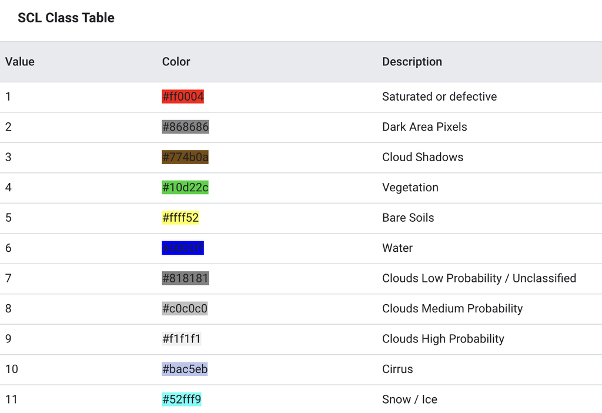

Amani, Meisam, Mohammad Kakooei, Arsalan Ghorbanian, Rebecca Warren, Sahel Mahdavi, Brian Brisco, Armin Moghimi, et al. 2022. “Forty Years of Wetland Status and Trends Analyses in the Great Lakes Using Landsat Archive Imagery and Google Earth Engine.” *Remote Sensing* 14 (15). https://doi.org/10.3390/rs14153778.

Drusch, M., U. Del Bello, S. Carlier, O. Colin, V. Fernandez, F. Gascon, B. Hoersch, et al. 2012. “Sentinel-2: ESA’s Optical High-Resolution Mission for GMES Operational Services.” *The Sentinel Missions - New Opportunities for Science* 120 (May): 25–36. https://doi.org/10.1016/j.rse.2011.11.026.

E. L. Hestir, J. A. Greenberg, and S. L. Ustin. 2012. “Classification Trees for Aquatic Vegetation Community Prediction from Imaging Spectroscopy.” *IEEE Journal of Selected Topics in Applied Earth Observations and Remote Sensing* 5 (5): 1572–84. https://doi.org/10.1109/JSTARS.2012.2200878.

Masek, J. G., E. F. Vermote, N. E. Saleous, R. Wolfe, F. G. Hall, K. F. Huemmrich, Feng Gao, J. Kutler, and Teng-Kui Lim. 2006. “A Landsat Surface Reflectance Dataset for North America, 1990-2000.” *IEEE Geoscience and Remote Sensing Letters* 3 (1): 68–72. https://doi.org/10.1109/LGRS.2005.857030.

Mohseni, Farzane, Meisam Amani, Pegah Mohammadpour, Mohammad Kakooei, Shuanggen Jin, and Armin Moghimi. 2023. “Wetland Mapping in Great Lakes Using Sentinel-1/2 Time-Series Imagery and DEM Data in Google Earth Engine.” *Remote Sensing* 15 (14). https://doi.org/10.3390/rs15143495.

V. L. Valenti, E. C. Carcelen, K. Lange, N. J. Russo, and B. Chapman. 2020. “Leveraging Google Earth Engine User Interface for Semiautomated Wetland Classification in the Great Lakes Basin at 10 m with Optical and Radar Geospatial Datasets.” *IEEE Journal of Selected Topics in Applied Earth Observations and Remote Sensing* 13: 6008–18. https://doi.org/10.1109/JSTARS.2020.3023901.

Vermote, Eric, Chris Justice, Martin Claverie, and Belen Franch. 2016. “Preliminary Analysis of the Performance of the Landsat 8/OLI Land Surface Reflectance Product.” *Remote Sensing of Environment* 185: 46–56. https://doi.org/https://doi.org/10.1016/j.rse.2016.04.008.

Visser, Fleur, Kerst Buis, Veerle Verschoren, and Jonas Schoelynck. 2018. “Mapping of Submerged Aquatic Vegetation in Rivers from Very High-Resolution Image Data, Using Object-Based Image Analysis Combined with Expert Knowledge.” *Hydrobiologia* 812 (1): 157–75. https://doi.org/10.1007/s10750-016-2928-y.

Wolter, Peter T., Carol A. Johnston, and Gerald J. Niemi. 2005. “Mapping Submergent Aquatic Vegetation in the US Great Lakes Using Quickbird Satellite Data.” *International Journal of Remote Sensing* 26 (23): 5255–74. https://doi.org/10.1080/01431160500219208.

Yang, Xiao, Tamlin M. Pavelsky, Matthew R. V. Ross, Stephanie R. Januchowski-Hartley, Wayana Dolan, Elizabeth H. Altenau, Michael Belanger, et al. 2022. “Mapping Flow-Obstructing Structures on Global Rivers.” *Water Resources Research* 58 (1): e2021WR030386. https://doi.org/10.1029/2021WR030386.